# R Project Report

November 9, 2018

# 1 Problem analysis

## 1.1 Introduction to poverty

The world has committed itself to intensive targets for reducing poverty by 2030. The goal to reduce poverty and its related side effects are specified in Sustainable Development Goal (SDG) number one of the total seventeen SDG’s set up in the 2030 Agenda for Sustainable Development. All seventeen goals and quantitative targets are meant to stimulate action over the next fifteen years in areas of critical importance for humanity and the planet [2].

## 1.2 UN Targets

The negative effects of poverty are enormous. Poverty and related effects slow down development within whole countries. Certain groups are disproportionately represented and face additional constraints, such as limited access to resources and capabilities in escaping poverty. These include women, persons with disabilities, children, and indigenous peoples.

- Target 1: By 2030, eradicate extreme poverty for all people everywhere, currently measured as people living on less than $1.25 a day.
- Target 2: By 2030, reduce at least by half the proportion of men, women and children of all ages living in poverty in all its dimensions according to national definitions.
- Target 3: Implement nationally appropriate social protection systems and measures for all, including floors, and by 2030 achieve substantial coverage of the poor and the vulnerable.
- Target 4: By 2030, ensure that all men and women, in particular the poor and the vulnerable, have equal rights to economic resources.
- Target 5: By 2030, build the resilience of the poor and those in vulnerable situations.

## 1.3 The role of data in battling poverty

To mobilise resources to overcome inequalities between developed and developing countries data is needed. Data is widely used within decision-making and forms the raw material for accountability of policies. Today, in the private sector, analysis of big data is common for example with consumer profiling and personalised services. Similar techniques are being adopted to gain real-time insights into people’s wellbeing and to target aid interventions to vulnerable groups [2]. Sources of data, if applied responsibly, can enable more evidence-based decision-making, hereby contributing to making progress on the Sustainable Development Goals (SDGs) [1].

This is where a problem lies for analysing the poverty problem. Within the World Development Indicators, a lot of data is missing on various indicators on poverty. According to the IEG, reaching the UN targets faces many obstacles, among one of them is the lack of regularly high-quality data. Of the 139 developing countries, 22 have no data for the past three decades, some 30 countries have not had a survey in the past decade, and 20 countries only have had one survey since 2000 [2].

What is even more striking, is that one third of these countries are in Sub-Saharan Africa, where poverty is most frequent. Furthermore, from the countries that are reporting new surveys, eighty percent are from middle-income economies or higher. Also, additions to the survey database have been declining in recent years and the number of surveys within five years of a given date are declining rapidly [2].

One of the problems of building and maintaining a usable poverty database are financial, it would cost around 30 million/year to continuously perform surveys in 77 lower income countries. But these costs are not the main problem. There is also an enormous lack of political will within the government to proper store poverty data. Political will covers a multitude of obstacles from a refusal to collect data to unwillingness to release data for analysis. Also, many surveys on poverty known to World Bank staff are not available to other analysts or even to the citizens of the country [3].

## 1.4 Goal of this report

The success of the Sustainable Development Goals will be judged on what the data is telling us about their current state. For SDG 1, this will be mainly done in achieving the headline indicator of extreme poverty reduction, which is the share the population in a country living under the extreme poverty line of 1.90 a day. Without better poverty data, collected more frequently, and open to all, we will never know if that goal can be achieved. This can be done by collecting data, but it would take a lot of time to gather all this data and process it. Therefore, the main goal of this report is constructing a predictive model on basis of indicators that are related to poverty. We also try to get it an insight in the current state of poverty around the world to determine if our model predictions are accurate enough.

## 1.5 Research questions

Our main research question is twofold. The main part is about constructing a model that predicts poverty for various countries around the world. Besides that, we try to explore the current state of poverty and the distribution of wealth around the world.

*Our main research question is:* *What was the development of poverty around the world since 1990 and can we predict the prevalence of extreme poverty within countries based on a predictive bayesian model?

*To answer this research, several sub questions are defined:*

## 1.6 Methodology

Within this report, we try to gain more insight behind the data of poverty around the world. First, we will clean and analyse the data by selecting the relevant indicators. By means of critical analysis and interpretation of figures and numbers, we try to find relations in the data to obtain useful indicators for our model. Also, relevant primary research on the topic of poverty will be included to compare our primary research findings.

R-studio is used as a tool to perform the data analysis within this research. R is widely used as a programming language for the visualisation of data. It contains additional packages that are very powerful for data analysis and visualisation purposes. Within our computations in R, several additional packages have been used. For example, Plotly has been used to make our detailed graphics. In Plotly visualisations are displayed in an efficient way and many possibilities to visualize the data are present. We also use several scripts provided within this course to estimate our model.

Resources [1] https://www.globalgoals.org/1-no-poverty [2] https://sdgcompass.org/sdgs/sdg-1 [3] https://ourworldindata.org/extreme-poverty [4] http://pubdocs.worldbank.org/en/109701443800596288/PRN03Oct2015TwinGoals.pdf [5] https://opendatawatch.com/blog/ending-poverty-needs-better-data/ [6] http://ieg.worldbankgroup.org/sites/default/files/Data/reports/poverty_focus_cp_1.pdf [7] 7https://qz.com/africa/1428639/world-banks-measure-of-poverty-is-flawed/ http://www.un.org/en/sections/issues-depth/big-data-sustainable-development/index.html

# 2 Data Understanding and Preperation

## 2.1 Initial data collection

Our data comes from World Development Indicators database(http://data.worldbank.org/data-catalog/world-development-indicators). On the website we could download the data, WDIData.csv. We focus on one of the UN Sustainable Development Goals: No Poverty. Data of over 1440 indicators of more than 200 countries and regions from 1960 to 2015 are provided in the WDI dataset, but only some of them are relevant to what we want to discuss about.

We encounter two problems when we try to acquire the data.

First, we narrow down the scope of indicators of the following fields that might be related to ‘No poverty’ goal. This includes the following indicators:

1. Poverty headcount and poverty gap: -Poverty headcount ratio at national poverty lines (% of population) -Rural poverty headcount ratio at national poverty lines (% of rural population) -Urban poverty headcount ratio at national poverty lines (% of urban population) -Poverty headcount ratio at $1.90 a day (2011 PPP) (% of population) -Poverty headcount ratio at $3.20 a day (2011 PPP) (% of population) -Poverty headcount ratio at $5.50 a day (2011 PPP) (% of population) -Poverty gap at $1.90 a day (2011 PPP) (%) -Poverty gap at $3.20 a day (2011 PPP) (%) -Poverty gap at $5.50 a day (2011 PPP) (%) -Poverty gap at national poverty lines (%)
2. Social welfare: -Coverage of social safety net programs (% of population) -Coverage of social insurance programs (% of population)
3. Indicators that we decidede to use (life expectation, education,economy)

Secondly, we choose to start our analysis in a world level to have a first sight into the data, and then focus on some certain countries with data in relatively abnormal trend.

Thirdly, we mostly use the data from 1990 to 2015. The number of people living in extreme poverty dropped by more than half between 1990 and 2015. We want to find out the exact trend of how poverty has changed in the word thought out that period. Further more, we try to quantify the correlation between poverty in certain countries and the social welfare system in those countries to have a basic knowledge on how effective the social programs are.

## 2.2 Data Description and quality problem

We assume that indicators about social safety program, education, life expectation, mortality rate of infants are related to the poverty situation in countries. And we also make the hypothesis that social safety program, education and life expectation have negative correlation with poverty, while mortality rate of infants is positively related to poverty. These indicators include scales of both social science and economy so that we could look into the properties of poverty with a broader scope. But in the indicators we choose, a lot of data is missing. We have two solutions on the missing data. The first solution is to drop off the data with missing part. The other way is to estimate the missing data with our regression model.

## 2.3 Loading, choosing and merging the data

After we load the data and using the file encoding type as UTF-8, we make several changes to make the dataset neater. We drop off all the final blank columns which contain no data at all.

```r
# Read the data in correctly
mydata_utf8 = read.table("WDI/WDIData.csv",sep=",",fileEncoding="UTF-8-BOM",header=TRUE)

# drop off the final blank column
mydata = mydata_utf8[,1:62]

all_code = unique(mydata[,1:2])
all_var = unique(mydata[,3:4])

# use the right countries
#country_code = read.table("data/WDI/country_code.csv",sep=",",header=FALSE)
# listing all our variables and group them by UN targets or characteristics
```

```r
Grouping_variables_population = list("SI.POV.NAGP","SP.RUR.TOTL.ZS","SP.POP.GROW","SP.POP.TOTL","SP.POP.TOTL.MA.IN","SP.POP.TOTL.FE.IN","SP.URB.TOTL.IN.ZS", "SI.POV.URHC", "SP.RUR.TOTL.ZS", "SI.POV.RUHC", "SI.POV.DDAY", "SP.POP.TOTL")

Predictor_variables = list("SP.DYN.LE00.IN","SE.XPD.TOTL.GD.ZS", "SE.XPD.TOTL.GD.ZS","SN.ITK.DEFC.ZS","SH.DYN.MORT")

Target_1_Headcount_Poverty_190_320_550 = list("SI.POV.DDAY","SI.POV.LMIC,SI.POV.UMIC","SI.POV.GAPS","SI.POV.LMIC.GP","SI.POV.UMIC.GP")

Target_2_National_Poverty_Lines_Indicator = list("SI.POV.NAHC","SI.POV.RUHC","SI.POV.URHC","SI.POV.NAGP","SI.POV.RUGP",
                                              "SI.POV.URGP")

Target_3_A_Social_insurance_programm = list("per_si_allsi.cov_pop_tot",
                                         "per_si_allsi.cov_q2_tot",
                                         "per_si_allsi.cov_q3_tot",
                                         "per_si_allsi.cov_q4_tot",
                                         "per_si_allsi.cov_q1_tot",
                                         "per_si_allsi.cov_q5_tot",
                                         "per_allsp.cov_pop_tot")

Target_3_B_Social_Safety_Net_programm = list("per_sa_allsa.cov_pop_tot",
                                          "per_sa_allsa.cov_q2_tot",
                                          "per_sa_allsa.cov_q3_tot",
                                          "per_sa_allsa.cov_q4_tot",
                                          "per_sa_allsa.cov_q1_tot",
                                          "per_sa_allsa.cov_q5_tot")

Target_3_C_Social_Safety_Net_programm = list("per_lm_alllm.cov_pop_tot",
                                          "per_lm_alllm.cov_q2_tot",
                                          "per_lm_alllm.cov_q3_tot",
                                          "per_lm_alllm.cov_q4_tot",
                                          "per_lm_alllm.cov_q1_tot",
                                          "per_lm_alllm.cov_q5_tot")

indicators_income_share = list("SI.DST.04TH.20","SI.DST.10TH.10","SI.DST.05TH.20","SI.DST.FRST.10",
                            "SI.DST.FRST.20","SI.DST.02ND.20","SI.DST.03RD.20")

indicators_economy = list("NY.GNP.PCAP.CD","NY.GNP.MKTP.CN","FP.CPI.TOTL.ZG","NY.GDP.DEFL.KD.ZG","NY.GDP.DEFL.KD.ZG.AD",
                       "TX.VAL.MRCH.CD.WT","TX.VAL.MRCH.WL.CD","TM.VAL.MRCH.CD.WT","TM.VAL.MRCH.WL.CD","SI.POV.GINI")

indicators_life_span = list("SH.DTH.IMRT","SP.DTH.INFR.ZS","SP.DTH.INFR.ZS","SP.DYN.TO65.FE.ZS","SP.DYN.TO65.MA.ZS",
                         "SP.DYN.IMRT.IN","SP.DYN.IMRT.FE.IN","SP.DYN.IMRT.MA.IN")

#putting all indicators names in one list to merge all lists with a loop, see below
List_of_indicators_list = list(Predictor_variables,indicators_life_span,indicators_economy,indicators_income_share, Target_3_C_Social_Safety_Net_programm,Target_3_B_Social_Safety_Net_programm,Target_3_A_Social_insurance_programm,Target_2_National_Poverty_Lines_Indicator,Target_1_Headcount_Poverty_190_320_550,Grouping_variables_population)

my_vars = list()
for (i in List_of_indicators_list ) {
  my_vars = append(my_vars,i)
}
my_vars_c = c(my_vars)
# subset the data
indicator_data = subset(mydata,mydata$Indicator.Code %in% my_vars_c)
# subset the data - selected var with only 1990 - 2015
indicator_data_1990_2015 = indicator_data[,c(2:3,4:4,35:60)]
```

## 2.4 Reshaping

But for purpose of easier use, we reshape the data into the format that in each row, there’s one value of an indicator in one country of one year, with the columns of country code, region, country name, indicator code, indicator name, year, and the value. This is also known as a wide to long format transformation. We delete the “X” in the name of years, for the potential usage of the scale of time in the temporal distribution in the following part in the report.

```r
colnames(indicator_data_1990_2015) <- sub("X", "", colnames(indicator_data_1990_2015))
our_indicator_data= melt(indicator_data_1990_2015,id=c("Indicator.Code","Indicator.Name","Country.Code"), value.name = "Year")
#setting up indicator data with country names from python @martijn
country_names = read.table("country_names.csv",sep = ",", header = TRUE)
country_wdi = country_names[,c(1:2,5:5)]

colnames(country_wdi) = c("Country.Code","Region","Region/Country Name")
our_indicator_data = merge(country_wdi,our_indicator_data,id = "Country.Code")
colnames(our_indicator_data)=c("Country.Code","Region","Country.Name","Indicator.Code","Indicator.Name","Year","Value")
```

And then we make a name list of the countries involved in the subset of indicators we choose. Also we want to make some analysis on the level of region level so we extract the name list of the regions as well.

```r
#Obtaining lists for information about regions and countries
all_region_and_country_codes=our_indicator_data[,1:3]
all_region_and_country_codes=unique(all_region_and_country_codes)
all_regions = subset(all_region_and_country_codes, all_region_and_country_codes$Region == "")
all_countries = subset(all_region_and_country_codes, all_region_and_country_codes$Region != "")

#did a work around because factor levels in R
general_regions = unique(all_countries['Region'])
region_list = c('Latin America & Caribbean','South Asia','Sub-Saharan Africa','Europe & Central Asia','Middle East & North Africa','East Asia & Pacific','North America')

#Subset to extract regions
regions_used = subset(all_regions, all_regions$'Region/Country Name' %in% region_list)
regions_used = regions_used[,-c(2)]
```

## 2.5 Data preparation for further graphs drawing

In this part we want to prepare the data for the bubble charts about poverty and life expectancy, which indicates the correlation between these two indicators. We calculate the Total population of people who live in poverty by multiple two indicators: all population in the country and the poverty headcount ratio at $1.90 a day.

```r
#making bubble chart of poverty 3.10 and life expectancy
var_i = c("SH.DYN.MORT","SI.POV.DDAY","SP.POP.TOTL")

#subset the data with only the world and the two indicators above about population and people in poverty and life expectancy
bubble_chart_1 = subset(our_indicator_data,our_indicator_data$'Indicator.Code' %in% var_i)
test <- subset(bubble_chart_1, select = c("Indicator.Code","Region", "Country.Name", "Country.Code", "Year", "Value"))
df_bubble = dcast(test,Country.Code + Country.Name + Region + Year ~ Indicator.Code, value.var ="Value")
df_bubble_2013 = df_bubble[which(df_bubble$Year == 2012),]
df_bubble_2013$SP.POP.TOTL = df_bubble_2013$SP.POP.TOTL/1000000
df_bubble_2013$SI.POV.DDAY = df_bubble_2013$SI.POV.DDAY/100
df_bubble_2013$TotalPopPov = df_bubble_2013$SI.POV.DDAY * df_bubble_2013$SP.POP.TOTL

colnames(df_bubble_2013) = c("Country.Code", "Country.Name","Region","Year","ChildMort", "Poverty","TotalPop","TotalPopPov")
```

In this chart we only want to discuss at the national level instead of at regional level, so we exclude all the regional data as well as any NA value. And then we fix the data to the format with two decimals.

```r
#omit NA's
df_bubble_2013_na = na.omit(df_bubble_2013)
#order to omit regions, only hold countries
df_bubble_2013_na = df_bubble_2013_na[order(df_bubble_2013_na$Region, df_bubble_2013_na$Country.Name),]
k = as.numeric(dim(df_bubble_2013_na))[1]
df_bubble_2013_na_se = df_bubble_2013_na[c(13:k),]
#fix values with to many decimals and poverty percentage value
df_bubble_2013_na_se$Poverty = df_bubble_2013_na_se$Poverty *100
df_bubble_2013_na_se$Poverty = round(df_bubble_2013_na_se$Poverty,2)
df_bubble_2013_na_se$TotalPop = round(df_bubble_2013_na_se$TotalPop,2)
df_bubble_2013_na_se$TotalPopPov = round(df_bubble_2013_na_se$TotalPopPov,2)
df_bubble_2013_na_se$ChildMort = round(df_bubble_2013_na_se$ChildMort,2)

#CODE FOR MAKING THE BUBBLE CHATY OF POVERTY AND LIFE EXPECTANCY
#making bubble chart of poverty 1.90 and life expectancy
var_i = c("SP.DYN.LE00.IN","SI.POV.DDAY","SP.POP.TOTL")

#subset the data with only the world and the two indicators above about population and people in poverty and life expectancy
graph_data = subset(our_indicator_data,our_indicator_data$'Indicator.Code' %in% var_i)
test <- subset(graph_data, select = c("Indicator.Code","Region", "Country.Name", "Country.Code", "Year", "Value"))
df_bubble = dcast(test,Country.Code + Country.Name + Region + Year ~ Indicator.Code, value.var ="Value")
df_bubble_2013 = df_bubble[which(df_bubble$Year == 2012),]
df_bubble_2013$SP.POP.TOTL = df_bubble_2013$SP.POP.TOTL/1000000
df_bubble_2013$SI.POV.DDAY = df_bubble_2013$SI.POV.DDAY/100
df_bubble_2013$TotalPopPov = df_bubble_2013$SI.POV.DDAY * df_bubble_2013$SP.POP.TOTL

colnames(df_bubble_2013) = c("Country.Code", "Country.Name","Region","Year","Poverty","LifeExpec","TotalPop","TotalPopPov")

#omit NA
df_bubble_2013_na = na.omit(df_bubble_2013)
#order to omit regions only hold countries
df_bubble_2013_na = df_bubble_2013_na[order(df_bubble_2013_na$Region, df_bubble_2013_na$Country.Name),]
k = as.numeric(dim(df_bubble_2013_na))[1]
df_bubble_2013_na = df_bubble_2013_na[c(13:k),]
#fix values with to many decimals and poverty percentage value
df_bubble_2013_na$Poverty = df_bubble_2013_na$Poverty *100
df_bubble_2013_na$Poverty = round(df_bubble_2013_na$Poverty,2)
df_bubble_2013_na$TotalPop = round(df_bubble_2013_na$TotalPop,2)
df_bubble_2013_na$TotalPopPov = round(df_bubble_2013_na$TotalPopPov,2)
df_bubble_2013_na$LifeExpec = round(df_bubble_2013_na$LifeExpec,2)
df_bubble=merge(df_bubble_2013_na,df_bubble_2013_na_se,id= "Country.Code", all.x = T)
```

# 3 Data exploration

## 3.1 The state of poverty in the world

In this part we choose the indicators of Poverty headcount ratio at $1.90 a day and the total population in the country. We make subset of those indicators and again omit any NA values. Then we calculate the polulation living under absolute poverty and show it by line graphs.

```r
#FOR THE LINECHART ABOUT ABSOLUTE POVERTY
world = c("WLD")
var_i = c("SI.POV.DDAY", "SP.POP.TOTL")
#subset the data with only the world and the two indicators above about population and people in poverty in %
graph_absolute = subset(our_indicator_data,our_indicator_data$'Indicator.Code' %in% var_i)
graph_absolute = subset(graph_absolute,graph_absolute$'Country.Code' %in% world)
graph_absolute = graph_absolute[,c(4:7)]
#split the indicator column into two columns
wide = dcast(graph_absolute,Year ~ Indicator.Code,  value.var = "Value")
#this is a workaround for getting for each year the value for the two indicators into the same row
#omit all na values
wide <- na.omit(wide)

#multiply the data to get the absolute number of people living in poverty
wide$absolute <- (wide$SI.POV.DDAY/100) * (wide$SP.POP.TOTL/(10^9))
wide$absolute = round(wide$absolute,3)

#add hover text
wide$hover = with(wide, paste( "Year:", Year ,
                               "<br> World population living in extreme poverty:",absolute,"M",
                               "<br> Share of global population:", SI.POV.DDAY,"%"))
```

```r
#layout
a <- list(
  title = "Years",
  showticklabels = TRUE,
  gridwidth = 2,
  autotick = F,
  dtick = 2,
  range = c(0,25),
  showline = T
)
b <- list(
  title = "Number of people living in poverty (1,90$ a day)",
  showticklabels = TRUE,
  gridwidth = 2,
  showline = T,
  range = c(0,2)
)
#plot the graph
plot_ly(wide, x = ~Year, y = ~absolute, text = ~hover ,type = 'scatter', mode = 'lines') %>%
  layout(xaxis = a, yaxis = b, title = 'Global population living in extreme poverty 1990 - 2015')
```

[interactive chart not shown]

### 3.1.1 Distribution over regions

Here we want to show the poverty gap in different regions. After deleting the rows with only NA value but not any data, we melt it to change the dataset from wide format to long format. Then we draw a stacked line chart based on the subset of data.

```r
poverty_gap_data <- subset(mydata,mydata$Indicator.Code=="SI.POV.GAPS")
poverty_gap_data_1990 <- poverty_gap_data[,c(1:3,4:4, 35:60)]
# remove the 'X' in the columns
colnames(poverty_gap_data_1990) <- sub("X", "", colnames(poverty_gap_data_1990))
#remove the rows without any data
poverty_gap_withoutNA <- poverty_gap_data_1990[-which(rowSums(is.na(poverty_gap_data_1990))>24),]
#reshape the data for drawing graphs
poverty_melt = melt(poverty_gap_withoutNA, id=c("Indicator.Code","Indicator.Name","Country.Code", "Country.Name"), value.name = "Year")
#stacked area graph
##poverty line $1.90, six regions in one graph
regions_melt <- subset(poverty_melt, Country.Name =="East Asia & Pacific" | Country.Name =="Europe & Central Asia"| Country.Name =="Latin America & Caribbean"| Country.Name =="Middle East & North Africa"| Country.Name =="South Asia"| Country.Name =="Sub-Saharan Africa")
```

Below, we provided an overview of recent poverty trends for the standard ISO-regions, as provided by the OECD. The figure provides regional estimates of poverty rates (i.e. the share of population in each region living below the International Poverty Line). The poverty gap correspond to the International Poverty Line, at 1.90 int.$ in 2011 PPP prices.

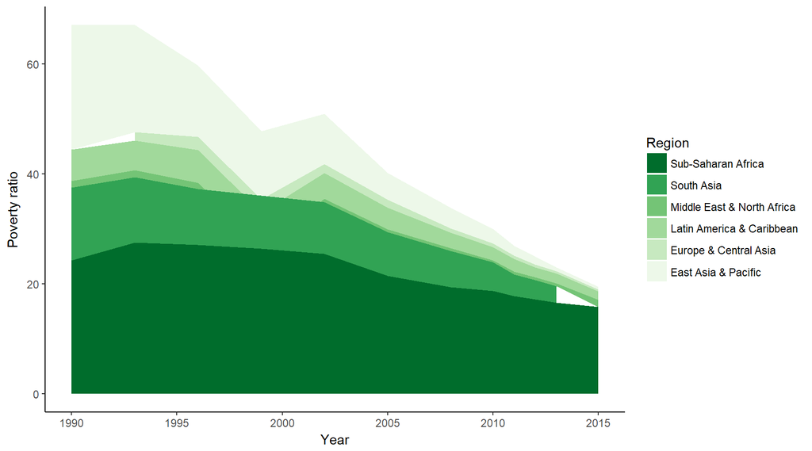

```r
gg <- ggplot(regions_melt, aes(x=as.numeric(as.character(variable)), y=value))
gg <- gg + geom_area(aes(fill=Country.Name))
#the color of the stacked area
gg = gg + scale_fill_brewer(palette="Greens", breaks=rev(levels(regions_melt$Country.Name)))
#label name
gg <- gg + labs(x="Year", y="Poverty ratio",col="Regions")
#label of the legend
gg <- gg + guides(fill = guide_legend(title = "Region"))
#remove the background and grid
gg <- gg + theme_bw() + theme(panel.border = element_blank(), panel.grid.major = element_blank(),
                              panel.grid.minor = element_blank(), axis.line = element_line(colour = "black"))
gg
```

### 3.1.2 Distribution all over the world

In the worldmap we only use the data of populations people in poverty from 2010 to 2015. To deal with the missing data, we choose to use the mean value of 6 years and use it as representative value. By doing that we have more data of population relating to poverty, while keeping the dtaa relatively acurate because we have a pool of data of the past 6 years.

```r
knitr::opts_chunk$set(echo = TRUE)

#selecting data from wdi + average of 6 years 2010 - 2015
var_i = c("SI.POV.DDAY","SP.POP.TOTL")
year = c('2010','2011', '2012','2013','2014','2015')

#subset the data with only the world and the two indicators above about population and people in poverty
geo_map_average = subset(our_indicator_data,our_indicator_data$'Indicator.Code' %in% var_i)
geo_map_average = subset(geo_map_average,geo_map_average$Year %in% year)
geo_map_average <- subset(geo_map_average, select = c("Indicator.Code","Country.Name", "Country.Code", "Year", "Value"))

#Calculate average over columns
df_mean_pov = dcast(geo_map_average,Country.Code + Country.Name + Indicator.Code ~ Year, value.var ="Value")
df_mean_pov['mean'] = rowMeans(df_mean_pov[,4:9],na.rm = T)
df_mean_pov = dcast(df_mean_pov,Country.Code + Country.Name  ~ Indicator.Code, value.var ="mean")
colnames(df_mean_pov) = c("Country.Code","Country.Name","MeanHeadCount","MeanPop")

#fix indicator values for plotting and calculate poverty population
df_mean_pov$MeanPop = df_mean_pov$MeanPop/1000000
df_mean_pov['MeanPovPop'] = df_mean_pov[,3]*(df_mean_pov[,4]/100)
df_mean_pov$MeanPop = round(df_mean_pov$MeanPop,2)
df_mean_pov$MeanHeadCount = round(df_mean_pov$MeanHeadCount,2)
df_mean_pov$MeanPovPop = round(df_mean_pov$MeanPovPop,2)
```

The worldmap is showing the prevalence of poverty displayed per country. What immediately attracks the eye are the big red spots in Africa, where the prevalence of poverty is the highest. However, there are also a lot of white spots, which represent missing data. To get an better idea of the real prevalence of poverty in Africa, we need to do something about that missing data.

```r
# light grey boundaries
l <- list(color = toRGB("grey"), width = 0.5)

df_mean_pov$hover <- with(df_mean_pov, paste
                                     ( "Year: 2015",'<br>',
                                       "Percentage under extreme poverty line:",MeanHeadCount,"%" ,'<br>',
                                       "Mean population living in extreme poverty:",MeanPovPop,"M",'<br>',
                                       "Total population:",MeanPop,"M",'<br>',
                                       "Country:", Country.Name))

# specify map projection/options
g <- list(
  showframe = F,
  resolution = 5,
  showcoastlines = T,
  countrycolor = toRGB("grey"),
  coastlinecolor = toRGB("grey"),
  projection = list(type = 'Mercator'))

k <- plot_geo(df_mean_pov) %>%
  add_trace(z = ~MeanHeadCount,text = ~hover, color = ~MeanHeadCount, colors= 'Reds',
            locations = ~Country.Code,
            marker = list(line = l,color = 'rgb(255,255,255)')) %>%

  colorbar(title = 'Percentage of total population living extreme poverty') %>%
  layout(title = 'Prevalance of Extreme Poverty during 2010 - 2015 (below 1.90$ a day)',geo = g)
k
```

[interactive chart not shown]

### 3.1.3 Distribution of wealth

The Multidimensional Poverty Index (MPI) published by the Oxford Poverty & Human Development Initiative (OPHI). The MPI is not aggregated at the country level, but at the individual level—it measures how one individual is deprived in different ‘poverty’ dimensions.

The MPI is constructed from ten indicators across three core dimensions: health, education and living standards. In the following map below, we plotted the share of MPI poor people country by country. The multidimensional poverty index not only uses regular economic indicators such as income, consumption and GINI data, but also non-economic indicators such as nutrition, electricity and schooling.

We choose only the data related to multi level poverty and we omit the last several columns without any data. Also we make an information table of which occurs when we put out mouse on a country and shows more related information on the country,such as country name, multi poverty index and child school attendance.

```r
#Selecting MDI Data, drop last 3 columns with no values
MPIData = read.table("MPIData.csv",sep=";",header=TRUE)
colnames(MPIData)[1] <- "CountryCode"
MPIData = MPIData[,1:20]

#Selecting MDI Data, drop last 3 columns with no values
MPIData2016 = read.table("MPIData2016.csv",sep=";",header=TRUE)
colnames(MPIData2016)[1] <- "PublishYear"

# light grey boundaries
l <- list(color = toRGB("grey"), width = 0.5)

MPIData2016$hover <- with(MPIData2016, paste
                      ( "Year:", SurveyYear,
                            "<br> Country:", Country,
                            "<br> Share of the pop. in Multi Level Poverty: ", Headcount.ratio ,"%",
                            "<br> Multi Poverty Index:", MPI,
                            "<br> Child school attendace:", ChildSchoolAttendance))
```

Source: https://ourworldindata.org/extreme-poverty#correlates-determinants-and-consequences

```r
# specify map projection/options
g <- list(
  showframe = F,
  resolution = 5,
  showcoastlines = T,
  countrycolor = toRGB("grey"),
  coastlinecolor = toRGB("grey"),
  projection = list(type = 'Mercator')
)

k <- plot_geo(MPIData2016) %>%
  add_trace(z = ~Headcount.ratio,text = ~hover, color = ~Headcount.ratio, colors = 'YlGnBu' ,
            locations = ~CountryCode,
            marker = list(line = l,color = 'rgb(255,255,255)')) %>%

  colorbar(show = F, title = 'Share of population living in MPI',legend = list(x = 100, y = 0.5),legend = list(orientation = 'h')) %>%
  layout(
    title = 'Share of population per country trapped in multi level poverty',
    geo = g )
k
```

[interactive chart not shown]

### 3.1.4 Plotting the gini indices

```r
#CODE FOR THE GINI INDICES
# subset the data - selected var GINI
indicator_datagini = subset(indicator_data,indicator_data$Indicator.Code=="SI.POV.GINI")

# LINE PLOT FOR THE COUNTRIES WITH THE HIGHEST GINI INDEXES
# extract the right years (25:60 is 1980 till 2015)
id = indicator_datagini[,c(2:3,4:4, 25:60)]
# remove the 'X' in the columns
colnames(id) <- sub("X", "", colnames(id))
# change the format
idm = melt(id, id=c("Indicator.Code","Indicator.Name","Country.Code"), value.name = "Year")
# throw away the rows with missing data
idm <- na.omit(idm, cols="value")
```

From the graph we can conclude that the Gini indices for the seven plotted countries in general oscilates between 35 and 65. We can also see that for the most countries there is not a lot of progression over the last 35 years. For example, Madagascar had a Gini index of 46,8 in 1980 and has a Gini index of 42,6 in 2012, while in the years in between the Gini index went up and down several times.

```r
#What countries have the lowest gini indices?
cl <- c("MDG","BDI","MWI","GNB","MOZ","ZMB","LSO")
# subset with only those countries
idmc <- subset(idm,idm$Country.Code %in% cl)
# plot the gini idexes of those countries over time
x <- list( title = "Years" )
y <- list( title = "Gini Index" )
m <- list(l=150, r=20, b=70, t=10)
pline <- plot_ly(idmc, x = ~idmc$variable, y = ~idmc$value, color = ~idmc$Country.Code) %>%
  add_lines(line = list(shape = "spline"))  %>% layout(xaxis = x, yaxis = y, margin=m)
pline
```

[interactive chart not shown]

### 3.1.5 Plotting the lorenz curve

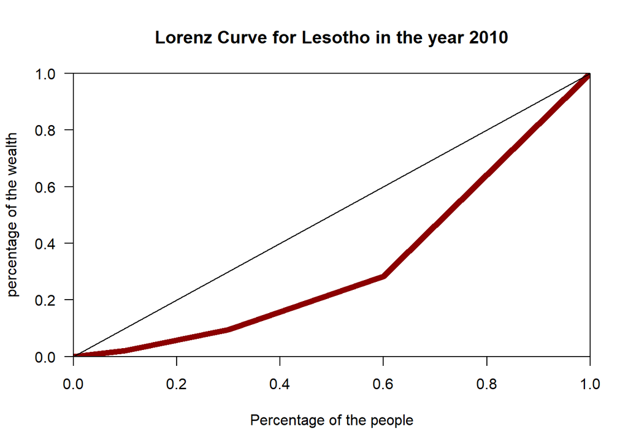

```r
# PLOT THE LORENZ CURVE OF ONE OF THE COUNTRIES (if a flat line occurs, there is no data)
# Get the indicators for the lorenz curve
my_var = c( "SI.DST.05TH.20","SI.DST.02ND.20","SI.DST.03RD.20", "SI.DST.04TH.20", "SI.DST.FRST.20")
# fill in country code in V1 and run code below
V1 = c("LSO")
# subset the data with only the country and the needed indicators
country_data = subset(indicator_data,indicator_data$Country.Code %in% V1)
COUNTRY_LC_V1 = subset(country_data,country_data$Indicator.Code %in% my_var)
# slice the needed data for the desirable year
COUNTRY_2015 = COUNTRY_LC_V1[,c(1:4,55:55)]
# create a vector for the lorenz curve function
p20 = c(0, 20, 40, 60 , 80,100)
# sort the values of the indicators. Make sure the year is the right one
d20 = sort(COUNTRY_2015$X2010)
# plot the lorenz curve
Lc.c <- Lc(d20, p20)
plot(Lc.c,col="darkred",lwd = 6, main = 'Lorenz Curve for Lesotho in the year 2010',xlab = 'Percentage of the people', ylab = 'percentage of the wealth')
```

```r
gini_index_country = Gini(d20)
```

## 3.2 Indicators for the model and their relation

Poverty has a strong relation with various outcomes of the society of a country. Therefore we have explored the data to find variables that are correlated with the prevelance of poverty, and we have plotted them in bubble graphs. These variables shall also be used in our predictive model.

### 3.2.1 Poverty and child mortality

```r
#determine size per bubble
slope <- 2.8e-6
df_bubble$size <- sqrt(df_bubble$Poverty * slope)*5000
colors = c('#FF934F','#FFD166','#5FCC8C','#EF6464','#5DCBEF','#8C6ACC','#CC6AAC')

p <- plot_ly(df_bubble, x = ~ChildMort, y = ~Poverty, color = ~Region, size = ~size, colors = colors,
             type = 'scatter', mode = 'markers', sizes = c(min(df_bubble$size), max(df_bubble$size)),
             marker = list(symbol = 'circle', sizemode = 'diameter',
                           line = list(width = 2, color = '#FFFFFF')),
             text = ~paste('Country:', Country.Name,
                           '<br> Region:', Region,
                           '<br> Childmortality under 5 per 1000 births: ', ChildMort,"%",
                           "<br> Percentage of population living in Extreme Poverty: ", Poverty,"%",
                           "<br> Total population living in Extreme Poverty:", TotalPopPov,"M",
                           '<br> Total population:', TotalPop, "M")) %>%
  layout(title = 'Childmortality and the prevalence of Extreme Poverty',
         xaxis = list(title = 'Childmortality under 5 per 1000 births',
                      gridcolor = 'rgb(255, 255, 255)',
                      zerolinewidth = 1,
                      ticklen = 4,
                      gridwidth = 2),
         yaxis = list(title = 'Prevalence of Poverty (%population)',
                      gridcolor = 'rgb(255, 255, 255)',
                      zerolinewidth = 1,
                      ticklen = 5,
                      gridwith = 2),
         paper_bgcolor = 'rgb(243, 243, 243)',
         plot_bgcolor = 'rgb(243, 243, 243)')
p
```

[interactive chart not shown]

### 3.2.2 Poverty correlates with health outcomes

Moreover, people who live in extreme poverty also have particularly bad health outcomes. Countries with a low life expectancy (by birth), generally have a high prevelance of extreme poverty. As we can see, there is a clear negative relationship: people tend to live longer in countries where poverty is less common. The bubbles are relative for the extreme poverty headcount. Yet the correlation is far from perfect. Some countries such as Madagascar and Congo have a similar poverty headcount but a very different life expectancy. The highest difference is between the countries Guinea and Iceland with a difference of (82,92 - 57,78 =) 25 years.

```r
#determine size per bubble
slope <- 2.8e-6
df_bubble$size <- sqrt(df_bubble$Poverty * slope)*5000
colors = c('#FF934F','#FFD166','#5FCC8C','#EF6464','#5DCBEF','#8C6ACC','#CC6AAC')

p <- plot_ly(df_bubble, x = ~LifeExpec, y = ~Poverty, color = ~Region, size = ~size, colors = colors,
             type = 'scatter', mode = 'markers', sizes = c(min(df_bubble$size), max(df_bubble$size)),
             marker = list(symbol = 'circle', sizemode = 'diameter',
                           line = list(width = 2, color = '#FFFFFF')),
             text = ~paste('Country:', Country.Name, '<br> Life expectance by birth', LifeExpec,"years", '<br>Region:', Region,
                           "<br> Percentage of population living in Extreme Poverty", Poverty,"%",
                           "<br> Total population living in Extreme Poverty:", TotalPopPov,"M",
                           '<br> Total population:', TotalPop, "M")) %>%
  layout(title = 'Life Expectancy and Extreme Poverty 2013',
         xaxis = list(title = 'Life expectancy in years (by birth)',
                      gridcolor = 'rgb(255, 255, 255)',
                      zerolinewidth = 1,
                      type = 'log',
                      ticklen = 4,
                      gridwidth = 2),
         yaxis = list(title = 'Prevalence of Poverty (% of population)',
                      gridcolor = 'rgb(255, 255, 255)',
                      zerolinewidth = 1,
                      ticklen = 5,
                      range = c(-15,100),
                      gridwith = 2),
         paper_bgcolor = 'rgb(243, 243, 243)',
         plot_bgcolor = 'rgb(243, 243, 243)')
p
```

[interactive chart not shown]

# 4 Model

```r
#selecting data from wdi
var_predictors = c("SP.DYN.LE00.IN","SN.ITK.DEFC.ZS","SH.DYN.MORT")

#subset the data with the three predicters
df_predictors = subset(our_indicator_data,our_indicator_data$'Indicator.Code' %in% var_predictors)
df_predictors = subset(df_predictors, select = c("Indicator.Code","Region","Country.Name", "Country.Code", "Year", "Value"))
df_predictors = dcast(df_predictors,Country.Code + Region + Country.Name + Year ~ Indicator.Code, value.var ="Value")
df_predictors = subset(df_predictors, df_predictors$Year==2015)
df_predictors = df_predictors[-which(rowSums(is.na(df_predictors))> 0),]
df_predictors = subset(df_predictors, df_predictors$Country.Code %in% all_countries$Country.Code)

#is the script Average poverty 2010 - 2015
#selecting data from wdi + average of 6 years 2010 - 2015 -----------
year = c('2010','2011', '2012','2013','2014','2015')
poverty_average = subset(our_indicator_data,our_indicator_data$'Indicator.Code' %in% "SI.POV.DDAY")
poverty_average = subset(poverty_average,poverty_average$Year %in% year)
poverty_average = subset(poverty_average, select = c("Indicator.Code","Country.Name", "Country.Code", "Year", "Value"))
#Calculate average over columns
poverty_average = dcast(poverty_average,Country.Code + Country.Name + Indicator.Code ~ Year, value.var ="Value")
poverty_average['Mean'] = rowMeans(poverty_average[,4:9],na.rm = T)
poverty_average = poverty_average[,c(1:2,10:10)]
#dropping zero's and NA's
poverty_average = na.omit(poverty_average)
poverty_average = poverty_average[apply(poverty_average!=0, 1, all),]
### ------------------------------------------------------------------

#combine the poverty dataframe with the predictors dataframe
poverty_JAGS = subset(poverty_average,poverty_average$Country.Code %in% df_predictors$Country.Code)
predictors_JAGS = subset(df_predictors,df_predictors$Country.Code %in% poverty_average$Country.Code)
df_jags_year = cbind(predictors_JAGS,poverty_JAGS$Mean)

#Select the predictors and the predicted value from the dataframe
poverty = df_jags_year$`poverty_JAGS$Mean`
life_expacteny = df_jags_year$SP.DYN.LE00.IN
undernourishment = df_jags_year$SN.ITK.DEFC.ZS
child_mortality = df_jags_year$SH.DYN.MORT
n = nrow(df_jags_year)

#standardize the values
y <- poverty
x1 <- undernourishment
x2 <- child_mortality
x3 <- life_expacteny
y  <- (y-mean(y))/sd(y)
x1 <- (x1-mean(x1))/sd(x1)
x2 <- (x2-mean(x2))/sd(x2)
x3 <- (x3-mean(x3))/sd(x3)

#Our model
model_string <- "model{

# Likelihood
for(i in 1:n){
y[i]  ~ dnorm(mu[i],inv.var1)
mu[i] <- beta1 + beta2*x1[i] + beta3*x2[i] + beta4*x3[i]
}

# Prior for beta
beta1 ~ dexp(0.072029)
beta2 ~ dexp(0.082930)       #undernourishment
beta3 ~ dexp(0.032092)       #child mortality
beta4 ~ dweib(14,74.74)      #life expactency

# Prior for the inverse variance
var1       ~   dunif(0,0.1)  #poverty
inv.var1   <-  1/var1
sigma1     <-  sqrt(var1)
}"

model <- jags.model(textConnection(model_string), data = list(y=y, x1=x1,x2=x2,x3=x3,n=n),n.chains = 4)
```

```r
update(model, 10000, progress.bar="none"); # Burn-in for 10000 samples

samp <- coda.samples(model,
                     variable.names=c("beta1","beta2","beta3","beta4","sigma1"),
                     n.iter=20000, progress.bar="text")

saveRDS(samp,"modelrun.rds")

#summary + plots
summary(samp)
```

```
Iterations = 11001:31000
Thinning interval = 1
Number of chains = 4
Sample size per chain = 20000

1. Empirical mean and standard deviation for each variable,
   plus standard error of the mean:

          Mean       SD  Naive SE Time-series SE
beta1  0.02344 0.017664 6.245e-05      6.256e-05
beta2  0.36950 0.039087 1.382e-04      2.126e-04
beta3  0.74065 0.055996 1.980e-04      5.049e-04
beta4  0.21768 0.047317 1.673e-04      4.553e-04
sigma1 0.31515 0.001073 3.793e-06      8.652e-06

2. Quantiles for each variable:

            2.5%      25%    50%     75%   97.5%
beta1  0.0009276 0.009363 0.0199 0.03385 0.06587
beta2  0.2929246 0.343065 0.3695 0.39589 0.44572
beta3  0.6340407 0.702332 0.7394 0.77760 0.85393
beta4  0.1323862 0.184494 0.2153 0.24815 0.31623
sigma1 0.3122600 0.314728 0.3155 0.31591 0.31620
```

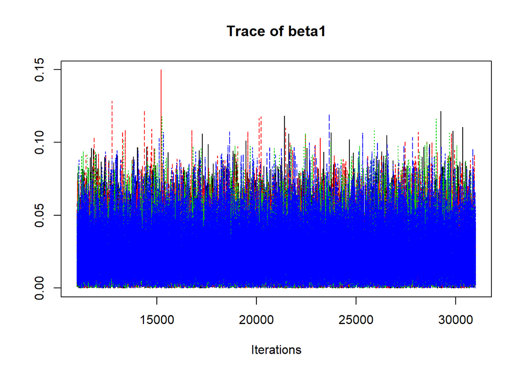

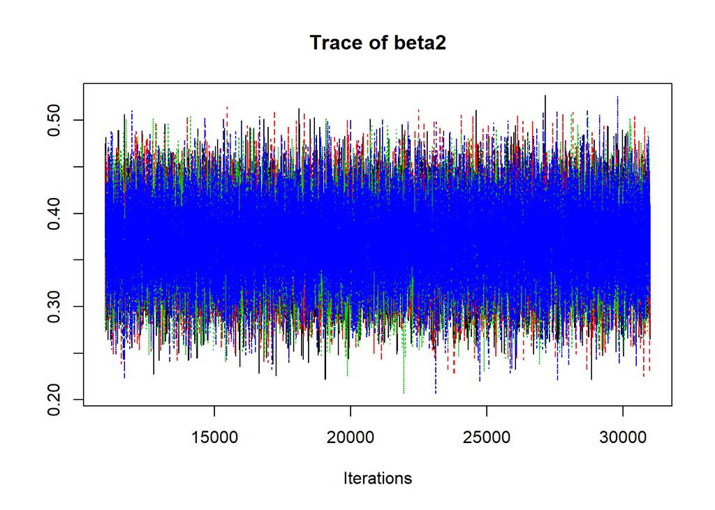

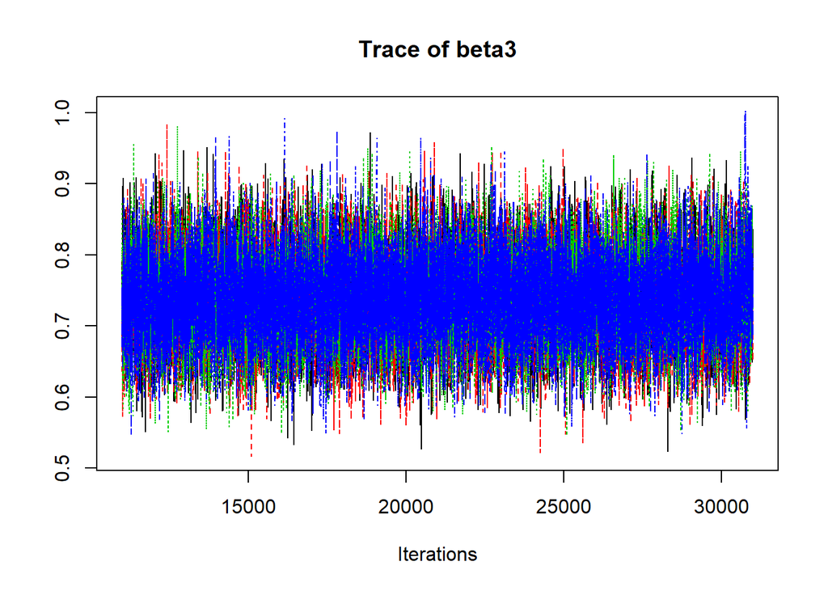

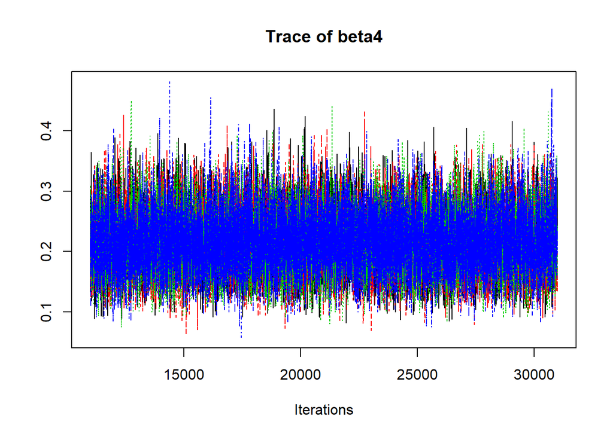

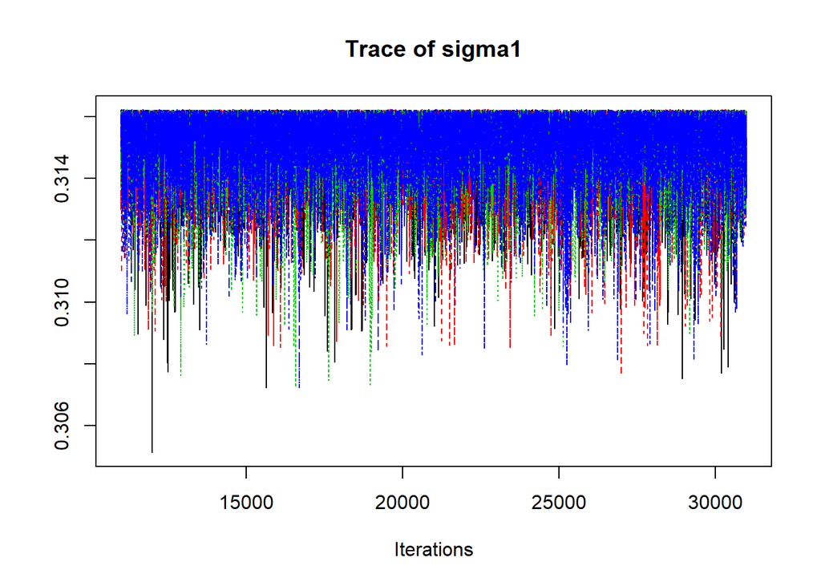

```r
traceplot(samp)
```

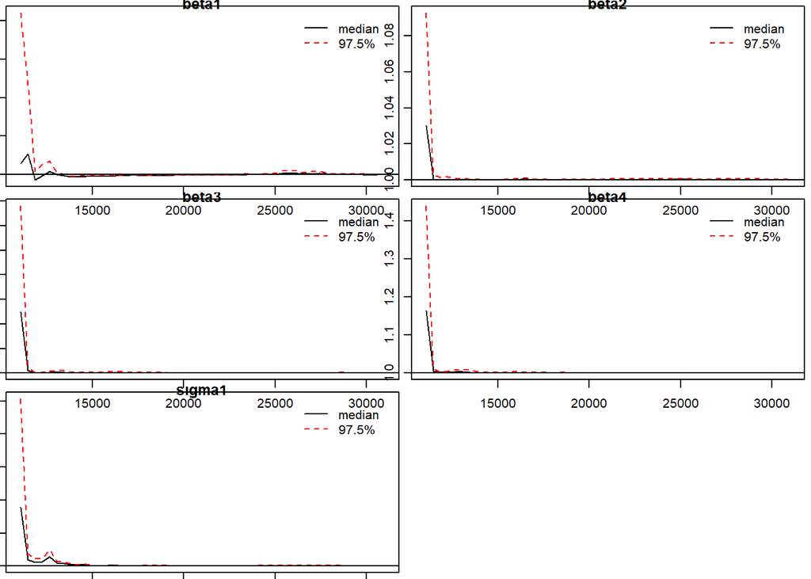

```r
par(mar=c(.4,.4,.4,.4))
gelman.plot(samp)
```

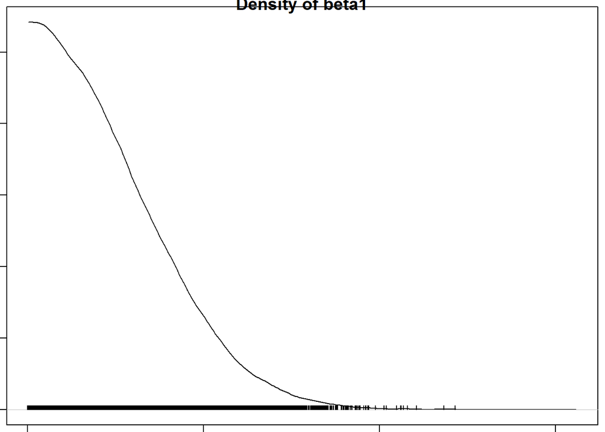

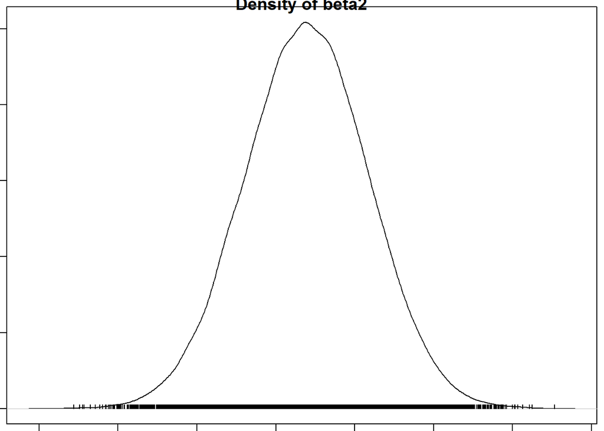

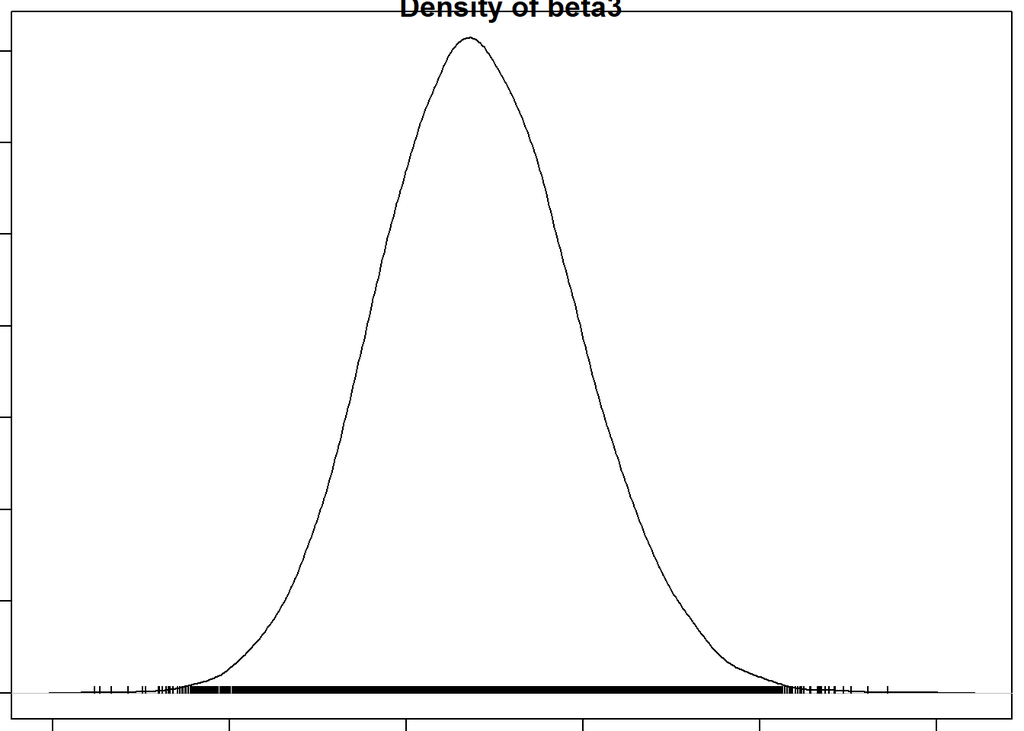

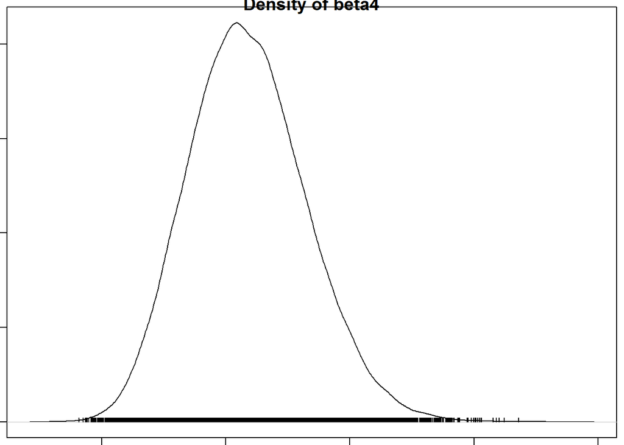

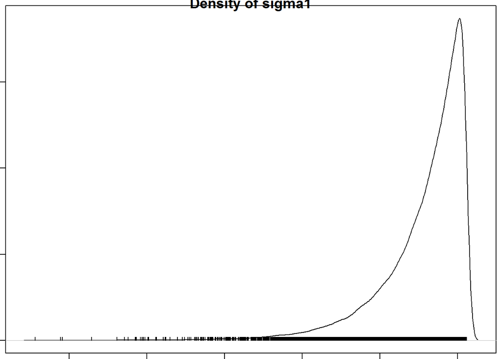

```r
densplot(samp)
```

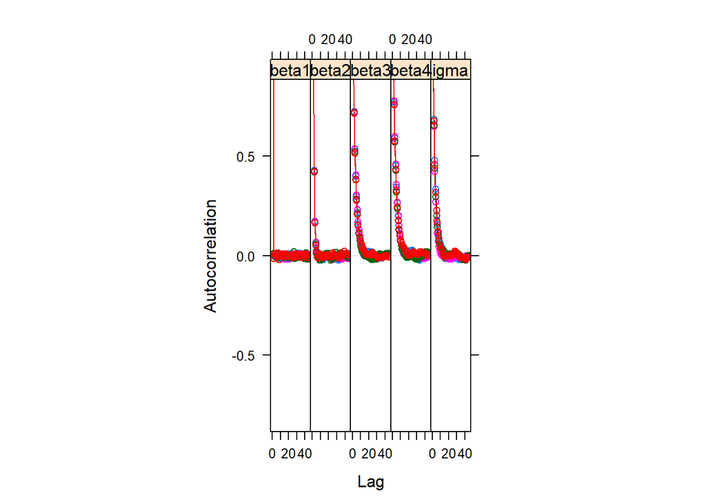

```r
acfplot(samp)
```

```r
effectiveSize(samp)
```

```
   beta1    beta2    beta3    beta4   sigma1
79736.31 33798.11 12320.50 10812.13 15464.59
```

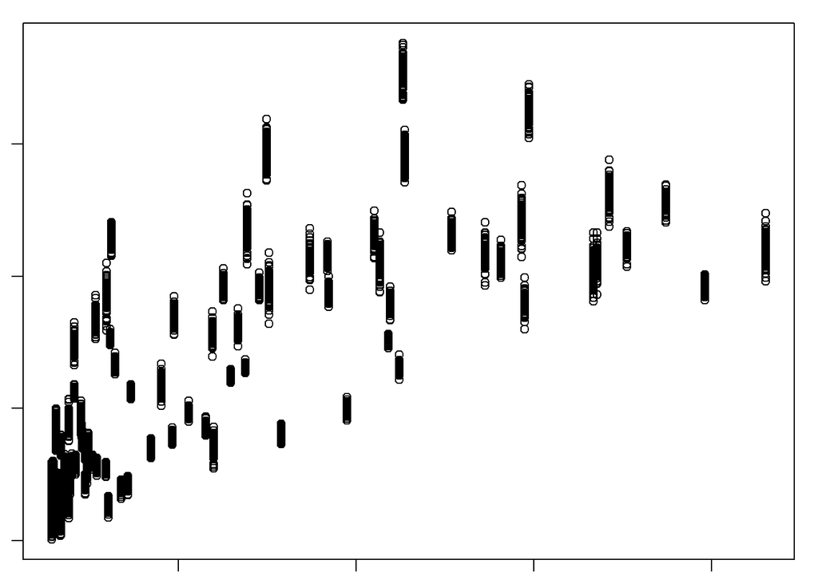

```r
###---- Predicting ----------------------------------------------------------

sampmatrix = as.matrix(samp)
# take the first four parameters, but drop off the noise!
param <-sampmatrix[sample(nrow(sampmatrix),size = 100, replace=FALSE),1:4]
# create a design matrix
n <- nrow(df_jags_year)
# make an intercept
intercept <- rep(1,n)
# bind your data together in the order used for modelling
data <- cbind(intercept,x1,x2,x3)
pred <- param %*% t(data)
pred <- t(pred)
# replicate the results
act <- rep(y,100)
par(mar=c(1,1,1,1))
plot(act,pred,xlab="Actual",ylab="Predicted")
```

```r
### ----- Filling in the NA -------------------------------------------------
#creates list with countries which have NA value on poverty
life_expactency2 = df_predictors$SP.DYN.LE00.IN
undernourishment2 = df_predictors$SN.ITK.DEFC.ZS
child_mortality2 = df_predictors$SH.DYN.MORT
n2 <- nrow(df_predictors)

#standardize these values
x21 <- life_expactency2
x22 <- undernourishment2
x23 <- child_mortality2
x21 <- (x21-mean(x21))/sd(x21)
x22 <- (x22-mean(x22))/sd(x22)
x23 <- (x23-mean(x23))/sd(x23)

# make an intercept
intercept2 <- rep(1,n2)
#predict the values for all the countries within the df_predictors dataset
data2 <- cbind(intercept2,x21,x22,x23)
pred2 <- param %*% t(data2)
pred2 <- t(pred2)
predicted = rowMeans(pred2[,0:100],na.rm = T)

predicted_poverty <- data.frame(
  c1 = df_predictors$Country.Code,
  c2 = df_predictors$Country.Name,
  c3 = predicted
)
names(predicted_poverty) <- c("Country.Code","Country.Name","score")

predicted_poverty$poverty = (predicted_poverty$score * sd(poverty)) + mean(poverty)
```

# 5 Evaluation

- evaluation Insights gained from the figures and graphs is useful because they play an important role in assissting policy makers and project implementers by revealing the poverty trend in the world, the potential causes of poverty, and thus helping evaluating the efforts put in targeting poverty alleviation.

# 6 Development

[output not shown]